# Fig 1F lower panel: Meta genes over UTRs, CDS and flank

Here are some different ways for showing the metagenes split out into different sections. We need to decide which we wish to show.

The first way is to split out into 5’ UTR, 3’ UTR and CDS. These are now effectively showing some sort of per-gene normalised fragments per base (a bit like FPKM, but instead of calculating the per million part across the whole sample, its calculated across each gene seperately). The results are below:

```r
library(RSQLite)
iclip_metagenes <- dbGetQuery(dbConnect(SQLite(), "/ifs/projects/proj028/project_pipeline_iCLIP5/csvdb"), "SELECT * FROM iclip_utrprofiles")
```

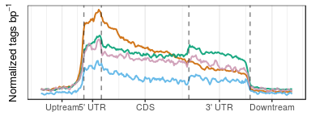

```r
filter(iclip_metagenes, replicate == "union", factor %in% c("Alyref", "Chtop", "Nxf1", "FlipIn")) %>%
  group_by(factor) %>%
  mutate(density=rollmean(density, 3, na.pad=TRUE)) %>%
ggplot() +
  aes(bin, density, col=factor) +
  geom_line(size=0.7, alpha=0.9) +
  scale_color_manual(values=factor_pal, guide=FALSE) +
  theme_bw(base_size=10) +
  geom_vline(xintercept = c(50,70,170,240), lty=2, alpha=0.5) +
  scale_x_continuous(breaks = c(25,60,120,205,265),
                     labels = c("Uptream", "5' UTR", "CDS", "3' UTR", "Downtream"),
                     name=NULL) +
  scale_y_continuous(breaks=NULL, name=expression(paste("Normalized tags ",bp^{-1}))) -> g
print(g)
```

Advantages:

- a good peak for for Alyref
- nice smooth profiles for all factors.
- FlipIn is also shown a being much less strong than the others (this is because area under the curve is proportaitonal to the nubmer of genes that have any reads)
- FlipIn doesn’t have much of a pattern to it.

Disadvanges:

- The 3’ enrichment for Chtop isn’t very apparent.
- Profiles decay towards the 3’ end of the 3’ UTR, presumably due to low expression.
- Both of these could be due to poor UTR annotation.

```r
nuclear_rna = iclip_metagenes %>%
  filter(factor == "Nuclear") %>%
  group_by(bin) %>%
  summarize(nuclear_rna=mean(density))
chromatin_rna = iclip_metagenes %>%
  filter(factor == "HEK293", tag=="WT",replicate=="1") %>%
  group_by(bin) %>%
  summarize(chromatin_rna=mean(density))
normed_clip = iclip_metagenes %>%
  inner_join(nuclear_rna) %>%
  inner_join(chromatin_rna) %>%
  mutate(normed_nuclear = density/nuclear_rna,
         normed_chromatin = density/chromatin_rna)
```

Advantages:

Disadvantages:

We could try using chromatin instead of nuclear RNA.

```r
filter(normed_clip, replicate == "union", factor %in% c("Alyref", "Chtop", "Nxf1", "FlipIn")) %>%
  group_by(factor) %>%
  mutate(normed=rollmean(normed_chromatin, 3, na.pad=TRUE)) %>%
ggplot() +
  aes(bin, normed, col=factor) +
  geom_line(size=0.7, alpha=0.9) +
  scale_color_manual(values=factor_pal, guide=FALSE) +
  theme_bw(base_size=10) +
  geom_vline(xintercept = c(50,70,170,240), lty=2, alpha=0.5) +
  scale_x_continuous(breaks = c(25,60,120,205,265),
                     labels = c("", "5' UTR", "CDS", "3' UTR", ""),
                     name=NULL) +
  scale_y_continuous(breaks=NULL, name=expression(paste("Normalized tags ",bp^{-1})))-> g

print(g)
```

[output not shown]

Advantages:

- Smooth decay of patterns btween regions.
- Low FlipIn
- Strong Chtop signal in 3’ UTR

Disadvantages:

- FlipIn signal shows some boost in both 3’ and 5’ UTRs
- Would mean introducing yet another dataset into the study that won’t be used anywhere else.

We could look at first, middle and last exons instead of 5UTR, CDS, 3UTR, built using protein coding genes with at least 3 exons.

```r
first_mid_last = iclip_metagenes <- dbGetQuery(dbConnect(SQLite(), "/ifs/projects/proj028/project_pipeline_iCLIP5/csvdb"), "SELECT * FROM iclip_firstmidlast")
```

```r
filter(first_mid_last, replicate == "union", factor %in% c("Alyref", "Chtop", "Nxf1", "FlipIn"),
       region != "introns") %>%
  group_by(factor) %>%
  mutate(bin=seq(from=0,to=289,by=1)) %>%
  group_by(factor) %>%
  mutate(density=rollmean(density, 3, na.pad=TRUE)) %>%
ggplot() +
  aes(bin, density, col=factor) +
  geom_line(size=0.7, alpha=0.9) +
  scale_color_manual(values=factor_pal, guide=FALSE) +
  theme_bw(base_size=10) +
  geom_vline(xintercept = c(50,70,170,240), lty=2, alpha=0.5) +
  scale_x_continuous(breaks = c(25,60,120,205,265),
                     labels = c("", "First", "Middle", "Last", ""),
                     minor_breaks = NULL,
                     name=NULL) +
  scale_y_continuous(breaks=NULL, name=expression(paste("Normalized tags ",bp^{-1}))) -> g

print(g)
```

[output not shown]

Advantages:

- Shows enrichment of Chtop at 3’ end well
- Good signal for Alyref in the first exon
- No signal for FlipIni n the last exon.

Disadvangages:

- That annoying dip at the end of the first exon!
- Some enrichment for FlipIn in the first exon.

The final way could be to show the above, but without the per-gene normalisation. This means that strongly expressed genes will now contribute more the signal, and the lowely expressed, noisy genes will not.

```r
first_mid_last_nonorm = iclip_metagenes <- dbGetQuery(dbConnect(SQLite(), "/ifs/projects/proj028/project_pipeline_iCLIP5/csvdb"), "SELECT * FROM iclip_firstmidlast_nonorm")
```

```r
filter(first_mid_last_nonorm, replicate == "union", factor %in% c("Alyref", "Chtop", "Nxf1", "FlipIn"),
       ) %>%
#  group_by(factor) %>%
#  mutate(bin=seq(from=0,to=289,by=1)) %>%
  group_by(factor) %>%
  mutate(density=rollmean(density, 3, na.pad=TRUE)) %>%
ggplot() +
  aes(bin, density, col=factor) +
  geom_line(size=0.7, alpha=0.9) +
  scale_color_manual(values=factor_pal, guide=FALSE) +
  theme_bw(base_size=10) +
  geom_vline(xintercept = c(50,70,170,270,340), lty=2, alpha=0.5) +
  scale_x_continuous(breaks = c(25,60,120,220,305,365),
                     labels = c("", "First", "Middle","Introns", "Last", ""),
                     minor_breaks = NULL,
                     name=NULL) +
  scale_y_continuous(breaks=NULL, name="Tags per bp") -> g

print(g)
```

[output not shown]

Advantages:

- Can show introns on same plot (in other they would have to be a seperate window)
- Shows how small FlipIn signal is compared to others

Disadvantages:

- Shows how weak Nxf1 signal is
- That discontinuity is stil there at the end of the first exon.
- ChTop is show as having a lower signal in the middle exons rather than a higher signal in the last exon.

Finally once profiles are computed this way, we could show actualy FPKM on the y axis:

```r
filter(first_mid_last_nonorm, replicate == "union", factor %in% c("Alyref", "Chtop", "Nxf1", "FlipIn"),
       ) %>%
#  group_by(factor) %>%
#  mutate(bin=seq(from=0,to=289,by=1)) %>%
  group_by(factor) %>%
  mutate(density=rollmean(density, 3, na.pad=TRUE)) %>%
  group_by(factor) %>%
  mutate(density=density/sum(density, na.rm=T)) %>%
ggplot() +
  aes(bin, density, col=factor) +
  geom_line(size=0.7, alpha=0.9) +
  scale_color_manual(values=factor_pal, guide=FALSE) +
  theme_bw(base_size=10) +
  geom_vline(xintercept = c(50,70,170,240), lty=2, alpha=0.5) +
 scale_x_continuous(breaks = c(25,60,120,220,305,365),
                     labels = c("", "First", "Middle","Introns", "Last", ""),
                     minor_breaks = NULL,
                     name=NULL) +
  scale_y_continuous(breaks=NULL, name="FPKM") -> g

print(g)
```

[output not shown]